# Capstone Project: Create a Customer Segmentation Report for Arvato Financial Services

In this project, you will analyze demographics data for customers of a mail-order sales company in Germany, comparing it against demographics information for the general population. You'll use unsupervised learning techniques to perform customer segmentation, identifying the parts of the population that best describe the core customer base of the company. Then, you'll apply what you've learned on a third dataset with demographics information for targets of a marketing campaign for the company, and use a model to predict which individuals are most likely to convert into becoming customers for the company. The data that you will use has been provided by our partners at Bertelsmann Arvato Analytics, and represents a real-life data science task.

The versions of those two datasets used in this project will include many more features and has not been pre-cleaned. You are also free to choose whatever approach you'd like to analyzing the data rather than follow pre-determined steps. In your work on this project, make sure that you carefully document your steps and decisions, since your main deliverable for this project will be a blog post reporting your findings.

```python
# import libraries here; add more as necessary
import numpy as np
import pandas as pd
import matplotlib.pyplot as plt
import seaborn as sns

from sklearn.preprocessing import MinMaxScaler
from sklearn.model_selection import train_test_split
from sklearn.metrics import fbeta_score, accuracy_score
from sklearn.linear_model import LogisticRegression
from sklearn.ensemble import RandomForestClassifier
from sklearn.svm import SVC
from sklearn.model_selection import GridSearchCV
from sklearn.metrics import make_scorer
from sklearn.ensemble import AdaBoostClassifier
from sklearn.base import clone

from sklearn.preprocessing import StandardScaler, OneHotEncoder
from sklearn.decomposition import PCA
from sklearn.cluster import KMeans

# magic word for producing visualizations in notebook
%matplotlib inline
```

## Part 0: Get to Know the Data

There are four data files associated with this project:

Each row of the demographics files represents a single person, but also includes information outside of individuals, including information about their household, building, and neighborhood. Use the information from the first two files to figure out how customers ("CUSTOMERS") are similar to or differ from the general population at large ("AZDIAS"), then use your analysis to make predictions on the other two files ("MAILOUT"), predicting which recipients are most likely to become a customer for the mail-order company.

The "CUSTOMERS" file contains three extra columns ('CUSTOMER_GROUP', 'ONLINE_PURCHASE', and 'PRODUCT_GROUP'), which provide broad information about the customers depicted in the file. The original "MAILOUT" file included one additional column, "RESPONSE", which indicated whether or not each recipient became a customer of the company. For the "TRAIN" subset, this column has been retained, but in the "TEST" subset it has been removed; it is against that withheld column that your final predictions will be assessed in the Kaggle competition.

Otherwise, all of the remaining columns are the same between the three data files. For more information about the columns depicted in the files, you can refer to two Excel spreadsheets provided in the workspace. One of them is a top-level list of attributes and descriptions, organized by informational category. The other is a detailed mapping of data values for each feature in alphabetical order.

In the below cell, we've provided some initial code to load in the first two datasets. Note for all of the `.csv` data files in this project that they're semicolon (`;`) delimited, so an additional argument in the [`read_csv()`](https://pandas.pydata.org/pandas-docs/stable/generated/pandas.read_csv.html) call has been included to read in the data properly. Also, considering the size of the datasets, it may take some time for them to load completely.

You'll notice when the data is loaded in that a warning message will immediately pop up. Before you really start digging into the modeling and analysis, you're going to need to perform some cleaning. Take some time to browse the structure of the data and look over the informational spreadsheets to understand the data values. Make some decisions on which features to keep, which features to drop, and if any revisions need to be made on data formats. It'll be a good idea to create a function with pre-processing steps, since you'll need to clean all of the datasets before you work with them.

```python
# load in the data
azdias = pd.read_csv('../../data/Term2/capstone/arvato_data/Udacity_AZDIAS_052018.csv', sep=';')
customers = pd.read_csv('../../data/Term2/capstone/arvato_data/Udacity_CUSTOMERS_052018.csv', sep=';')
```

```
/opt/conda/lib/python3.6/site-packages/IPython/core/interactiveshell.py:2785: DtypeWarning: Columns (18,19) have mixed types. Specify dtype option on import or set low_memory=False.
  interactivity=interactivity, compiler=compiler, result=result)
```

```python
# check the structure of each dataframe --> rows and columns
print(azdias.shape)
print(customers.shape)
```

```
(891221, 366)
(191652, 369)
```

```python
azdias.describe()
```

|  | LNR | AGER_TYP | AKT_DAT_KL | ALTER_HH | ALTER_KIND1 | ALTER_KIND2 | ALTER_KIND3 | ALTER_KIND4 | ALTERSKATEGORIE_FEIN | ANZ_HAUSHALTE_AKTIV | ... | VHN | VK_DHT4A | VK_DISTANZ | VK_ZG11 | W_KEIT_KIND_HH | WOHNDAUER_2008 | WOHNLAGE | ZABEOTYP | ANREDE_KZ | ALTERSKATEGORIE_GROB |
| --- | --- | --- | --- | --- | --- | --- | --- | --- | --- | --- | --- | --- | --- | --- | --- | --- | --- | --- | --- | --- | --- |
| count | 8.912210e+05 | 891221.000000 | 817722.000000 | 817722.000000 | 81058.000000 | 29499.000000 | 6170.000000 | 1205.000000 | 628274.000000 | 798073.000000 | ... | 770025.000000 | 815304.000000 | 815304.000000 | 815304.000000 | 783619.000000 | 817722.000000 | 798073.000000 | 891221.000000 | 891221.000000 | 891221.000000 |
| mean | 6.372630e+05 | -0.358435 | 4.421928 | 10.864126 | 11.745392 | 13.402658 | 14.476013 | 15.089627 | 13.700717 | 8.287263 | ... | 2.417322 | 6.001214 | 7.532130 | 5.945972 | 3.933406 | 7.908791 | 4.052836 | 3.362438 | 1.522098 | 2.777398 |
| std | 2.572735e+05 | 1.198724 | 3.638805 | 7.639683 | 4.097660 | 3.243300 | 2.712427 | 2.452932 | 5.079849 | 15.628087 | ... | 1.166572 | 2.856091 | 3.247789 | 2.771464 | 1.964701 | 1.923137 | 1.949539 | 1.352704 | 0.499512 | 1.068775 |
| min | 1.916530e+05 | -1.000000 | 1.000000 | 0.000000 | 2.000000 | 2.000000 | 4.000000 | 7.000000 | 0.000000 | 0.000000 | ... | 0.000000 | 1.000000 | 1.000000 | 1.000000 | 0.000000 | 1.000000 | 0.000000 | 1.000000 | 1.000000 | 1.000000 |
| 25% | 4.144580e+05 | -1.000000 | 1.000000 | 0.000000 | 8.000000 | 11.000000 | 13.000000 | 14.000000 | 11.000000 | 1.000000 | ... | 2.000000 | 3.000000 | 5.000000 | 4.000000 | 2.000000 | 8.000000 | 3.000000 | 3.000000 | 1.000000 | 2.000000 |
| 50% | 6.372630e+05 | -1.000000 | 3.000000 | 13.000000 | 12.000000 | 14.000000 | 15.000000 | 15.000000 | 14.000000 | 4.000000 | ... | 2.000000 | 6.000000 | 8.000000 | 6.000000 | 4.000000 | 9.000000 | 3.000000 | 3.000000 | 2.000000 | 3.000000 |
| 75% | 8.600680e+05 | -1.000000 | 9.000000 | 17.000000 | 15.000000 | 16.000000 | 17.000000 | 17.000000 | 17.000000 | 9.000000 | ... | 3.000000 | 9.000000 | 10.000000 | 8.000000 | 6.000000 | 9.000000 | 5.000000 | 4.000000 | 2.000000 | 4.000000 |
| max | 1.082873e+06 | 3.000000 | 9.000000 | 21.000000 | 18.000000 | 18.000000 | 18.000000 | 18.000000 | 25.000000 | 595.000000 | ... | 4.000000 | 11.000000 | 13.000000 | 11.000000 | 6.000000 | 9.000000 | 8.000000 | 6.000000 | 2.000000 | 9.000000 |

8 rows × 360 columns

```python
customers.describe()
```

|  | LNR | AGER_TYP | AKT_DAT_KL | ALTER_HH | ALTER_KIND1 | ALTER_KIND2 | ALTER_KIND3 | ALTER_KIND4 | ALTERSKATEGORIE_FEIN | ANZ_HAUSHALTE_AKTIV | ... | VK_DHT4A | VK_DISTANZ | VK_ZG11 | W_KEIT_KIND_HH | WOHNDAUER_2008 | WOHNLAGE | ZABEOTYP | ONLINE_PURCHASE | ANREDE_KZ | ALTERSKATEGORIE_GROB |
| --- | --- | --- | --- | --- | --- | --- | --- | --- | --- | --- | --- | --- | --- | --- | --- | --- | --- | --- | --- | --- | --- |
| count | 191652.000000 | 191652.000000 | 145056.000000 | 145056.000000 | 11766.000000 | 5100.000000 | 1275.000000 | 236.000000 | 139810.000000 | 141725.000000 | ... | 143781.000000 | 143781.000000 | 143781.000000 | 137910.000000 | 145056.000000 | 141725.000000 | 191652.000000 | 191652.000000 | 191652.000000 | 191652.000000 |
| mean | 95826.500000 | 0.344359 | 1.747525 | 11.352009 | 12.337243 | 13.672353 | 14.647059 | 15.377119 | 10.331579 | 4.965863 | ... | 4.374417 | 4.564769 | 3.168868 | 4.152716 | 8.646371 | 3.723133 | 2.576806 | 0.090247 | 1.376432 | 3.060907 |
| std | 55325.311233 | 1.391672 | 1.966334 | 6.275026 | 4.006050 | 3.243335 | 2.753787 | 2.307653 | 4.134828 | 14.309694 | ... | 2.924355 | 2.887035 | 2.233516 | 1.974375 | 1.154001 | 2.095540 | 1.168486 | 0.286536 | 0.484492 | 1.086254 |
| min | 1.000000 | -1.000000 | 1.000000 | 0.000000 | 2.000000 | 2.000000 | 5.000000 | 8.000000 | 0.000000 | 0.000000 | ... | 1.000000 | 1.000000 | 1.000000 | 0.000000 | 1.000000 | 0.000000 | 1.000000 | 0.000000 | 1.000000 | 1.000000 |
| 25% | 47913.750000 | -1.000000 | 1.000000 | 8.000000 | 9.000000 | 11.000000 | 13.000000 | 14.000000 | 9.000000 | 1.000000 | ... | 2.000000 | 2.000000 | 1.000000 | 2.000000 | 9.000000 | 2.000000 | 1.000000 | 0.000000 | 1.000000 | 3.000000 |
| 50% | 95826.500000 | 0.000000 | 1.000000 | 11.000000 | 13.000000 | 14.000000 | 15.000000 | 16.000000 | 10.000000 | 1.000000 | ... | 4.000000 | 4.000000 | 3.000000 | 5.000000 | 9.000000 | 3.000000 | 3.000000 | 0.000000 | 1.000000 | 3.000000 |
| 75% | 143739.250000 | 2.000000 | 1.000000 | 16.000000 | 16.000000 | 16.000000 | 17.000000 | 17.000000 | 13.000000 | 4.000000 | ... | 7.000000 | 7.000000 | 4.000000 | 6.000000 | 9.000000 | 5.000000 | 3.000000 | 0.000000 | 2.000000 | 4.000000 |
| max | 191652.000000 | 3.000000 | 9.000000 | 21.000000 | 18.000000 | 18.000000 | 18.000000 | 18.000000 | 25.000000 | 523.000000 | ... | 11.000000 | 13.000000 | 11.000000 | 6.000000 | 9.000000 | 8.000000 | 6.000000 | 1.000000 | 2.000000 | 9.000000 |

8 rows × 361 columns

## Part 0.1: Data Preprocessing

- Drop unnecessary columns
- Handle missing values
- Convert categorical variables to numerical (one-hot encoding or label encoding)
- Standardize or normalize numerical data
- Handle outliers
- Feature engineering (if needed)

### Identify and drop unecessary columns

```python
information = pd.read_excel('DIAS Information Levels - Attributes 2017.xlsx', header=1)
information = information.dropna(subset=['Information level'])

print(information.shape)

attributes = pd.read_excel('DIAS Attributes - Values 2017.xlsx', header=1)
attributes = attributes.dropna(subset=['Attribute'])
print(attributes.shape)
```

```
(10, 4)
(314, 4)
```

```python
features = attributes['Attribute'].tolist()

azdias_cols_no_feature = list(set(azdias) - set(features))
azdias_cols_no_feature
```

```
['ALTER_KIND2',
 'ALTERSKATEGORIE_FEIN',
 'D19_KONSUMTYP_MAX',
 'D19_TELKO_MOBILE',
 'HH_DELTA_FLAG',
 'D19_SCHUHE',
 'D19_SAMMELARTIKEL',
 'D19_TELKO_REST',
 'VHA',
 'RT_SCHNAEPPCHEN',
 'KBA13_CCM_1401_2500',
 'FIRMENDICHTE',
 'D19_GARTEN',
 'KBA13_ANTG3',
 'KBA13_GBZ',
 'D19_REISEN',
 'D19_TIERARTIKEL',
 'CJT_KATALOGNUTZER',
 'CJT_TYP_1',
 'D19_VERSI_ONLINE_QUOTE_12',
 'D19_VERSICHERUNGEN',
 'KBA13_ANTG2',
 'D19_RATGEBER',
 'CAMEO_INTL_2015',
 'D19_VERSI_DATUM',
 'D19_VOLLSORTIMENT',
 'ANZ_STATISTISCHE_HAUSHALTE',
 'UMFELD_JUNG',
 'D19_SOZIALES',
 'ARBEIT',
 'D19_BANKEN_GROSS',
 'D19_FREIZEIT',
 'CJT_TYP_4',
 'ALTER_KIND4',
 'D19_VERSAND_REST',
 'ALTER_KIND1',
 'D19_LEBENSMITTEL',
 'D19_KINDERARTIKEL',
 'D19_VERSI_ONLINE_DATUM',
 'VK_DISTANZ',
```

[output cut: 39 more lines]

```
 'ALTER_KIND3',
 'D19_BUCH_CD',
 'KK_KUNDENTYP',
 'ANZ_KINDER',
 'CJT_TYP_3',
 'D19_NAHRUNGSERGAENZUNG',
 'KBA13_BAUMAX',
 'EINGEZOGENAM_HH_JAHR',
 'KBA13_ANTG4',
 'UNGLEICHENN_FLAG',
 'KBA13_HHZ',
 'D19_KOSMETIK',
 'D19_DROGERIEARTIKEL',
 'DSL_FLAG',
 'VK_ZG11']
```

```python
azdias = azdias.drop(columns=azdias_cols_no_feature, errors='ignore')
```

I want to delete any columns that aren't in the attibute sheet since I won't be able to fully understand the purpose of the column and can't be confident in my ability to handle any missing values or re-encoding the data

```python
# Assess how much missing data there is in each df
anulls = azdias.isnull().sum().sort_values(ascending=False)
anulls.head(10)
```

```
D19_BANKEN_ONLINE_QUOTE_12     257113
D19_KONSUMTYP                  257113
D19_GESAMT_ONLINE_QUOTE_12     257113
D19_VERSAND_ONLINE_QUOTE_12    257113
KBA05_MAXHERST                 133324
KBA05_MOTOR                    133324
KBA05_MOD8                     133324
KBA05_MOD3                     133324
KBA05_MOD2                     133324
KBA05_MOD1                     133324
dtype: int64
```

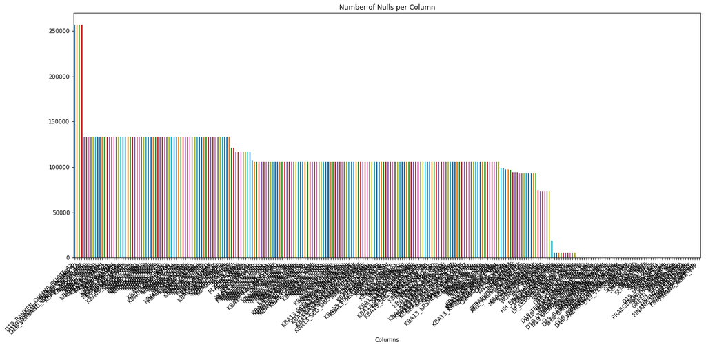

```python
# visualize nulls to find patterns and likely variables to remove
plt.figure(figsize=(20,8))
anulls.plot(kind='bar')
plt.title('Number of Nulls per Column')
plt.xlabel('Columns')
plt.xticks(rotation=45, ha='right')
plt.show()
```

While there are way too many columns for us to read the data, we can deduce that there are a number of columns with a significant portion of missing values that can be dropped

```python
# Assess how much missing data there is in each df
cnulls = customers.isnull().sum().sort_values(ascending=False)
cnulls.head(10)
```

```
ALTER_KIND4     191416
ALTER_KIND3     190377
ALTER_KIND2     186552
ALTER_KIND1     179886
KK_KUNDENTYP    111937
EXTSEL992        85283
KBA05_SEG7       55980
KBA05_KW1        55980
KBA05_SEG4       55980
KBA05_SEG5       55980
dtype: int64
```

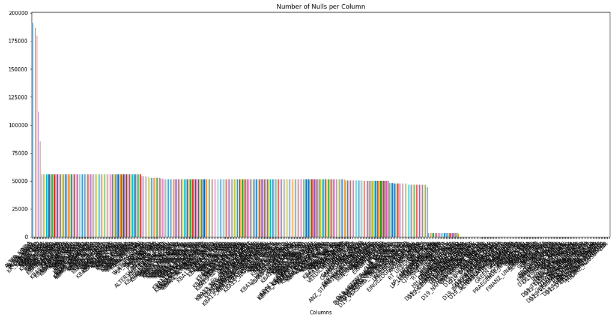

```python
# visualize nulls to find patterns and likely variables to remove
plt.figure(figsize=(20,8))
cnulls.plot(kind='bar')
plt.title('Number of Nulls per Column')
plt.xlabel('Columns')
plt.xticks(rotation=45, ha='right')
plt.show()
```

Here we still have a number of columns that need to be dropped by the number of columns is less than in the azdias df

```python
def percent_missing(df):
    """
    inputs: dataframe to be analyzed for percent of values missing from a given column
    outputs: each column and the percent of missing values
    """

    nan_detail = []

    for col in df.columns:
        nan_count = df[col].isna().sum()
        total_count = len(df)
        nan_percent = (nan_count/total_count)*100
        nan_detail.append([col, nan_percent])

    return nan_detail
```

```python
# Identify percent of columns missing from each dataframe and remove
azdias_percent_missing = percent_missing(azdias)

azdias_percent_missing = pd.DataFrame(azdias_percent_missing, columns=['Column', 'NaN Percentage']).sort_values(by='NaN Percentage', ascending=False)
print(azdias_percent_missing.head(10))

customers_percent_missing = percent_missing(customers)

customers_percent_missing = pd.DataFrame(customers_percent_missing, columns=['Column', 'NaN Percentage']).sort_values(by='NaN Percentage', ascending=False)
print(customers_percent_missing.head(10))
```

```
                         Column  NaN Percentage
15   D19_BANKEN_ONLINE_QUOTE_12       28.849522
33  D19_VERSAND_ONLINE_QUOTE_12       28.849522
22                D19_KONSUMTYP       28.849522
21   D19_GESAMT_ONLINE_QUOTE_12       28.849522
84                    KBA05_KW1       14.959701
82                 KBA05_KRSVAN       14.959701
81                KBA05_KRSOBER       14.959701
80               KBA05_KRSKLEIN       14.959701
79              KBA05_KRSHERST3       14.959701
78              KBA05_KRSHERST2       14.959701
              Column  NaN Percentage
7        ALTER_KIND4       99.876860
6        ALTER_KIND3       99.334732
5        ALTER_KIND2       97.338927
4        ALTER_KIND1       93.860748
300     KK_KUNDENTYP       58.406382
100        EXTSEL992       44.498883
148    KBA05_KRSOBER       29.209192
144  KBA05_KRSHERST1       29.209192
136        KBA05_GBZ       29.209192
137     KBA05_HERST1       29.209192
```

```python
# here I am going to delect to remove columns with more than 28% of records missing
threshold = 28

azdias_drop_columns = azdias_percent_missing[azdias_percent_missing['NaN Percentage'] > threshold]['Column']
customers_drop_columns = customers_percent_missing[customers_percent_missing['NaN Percentage'] > threshold]['Column']

azdias.drop(columns=azdias_drop_columns, inplace=True)
customers.drop(columns=customers_drop_columns, inplace=True)
```

Based on the above printouts and visualizations, I am going to remove any colums with more than 28% of records missing so that I don't ake assumptions with imputing the data that may incorrectly inform my model about its predictions

```python
# check new shapes after droping columns
print(azdias.shape)
print(customers.shape)
```

```
(891221, 268)
(191652, 294)
```

### Identify and drop incomplete rows

```python
# How much data is missing in each row of the dataset?
azdias['NaN Count Raw'] = azdias.isnull().sum(axis=1)
azdias.head(5)
```

|  | AGER_TYP | ALTER_HH | ANZ_HAUSHALTE_AKTIV | ANZ_HH_TITEL | ANZ_PERSONEN | ANZ_TITEL | BALLRAUM | CAMEO_DEU_2015 | CAMEO_DEUG_2015 | CJT_GESAMTTYP | ... | SHOPPER_TYP | TITEL_KZ | VERS_TYP | W_KEIT_KIND_HH | WOHNDAUER_2008 | WOHNLAGE | ZABEOTYP | ANREDE_KZ | ALTERSKATEGORIE_GROB | NaN Count Raw |
| --- | --- | --- | --- | --- | --- | --- | --- | --- | --- | --- | --- | --- | --- | --- | --- | --- | --- | --- | --- | --- | --- |
| 0 | -1 | NaN | NaN | NaN | NaN | NaN | NaN | NaN | NaN | 2.0 | ... | -1 | NaN | -1 | NaN | NaN | NaN | 3 | 1 | 2 | 203 |
| 1 | -1 | 0.0 | 11.0 | 0.0 | 2.0 | 0.0 | 6.0 | 8A | 8 | 5.0 | ... | 3 | 0.0 | 2 | 3.0 | 9.0 | 4.0 | 5 | 2 | 1 | 0 |
| 2 | -1 | 17.0 | 10.0 | 0.0 | 1.0 | 0.0 | 2.0 | 4C | 4 | 3.0 | ... | 2 | 0.0 | 1 | 3.0 | 9.0 | 2.0 | 5 | 2 | 3 | 0 |
| 3 | 2 | 13.0 | 1.0 | 0.0 | 0.0 | 0.0 | 4.0 | 2A | 2 | 2.0 | ... | 1 | 0.0 | 1 | NaN | 9.0 | 7.0 | 3 | 2 | 4 | 1 |
| 4 | -1 | 20.0 | 3.0 | 0.0 | 4.0 | 0.0 | 2.0 | 6B | 6 | 5.0 | ... | 2 | 0.0 | 2 | 2.0 | 9.0 | 3.0 | 4 | 1 | 3 | 0 |

5 rows × 269 columns

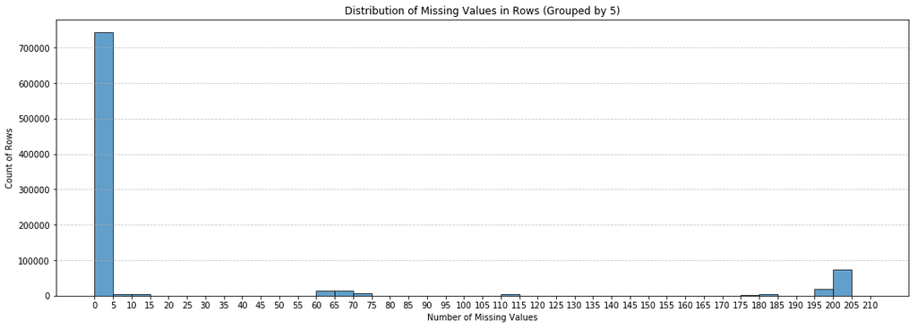

```python
# visualize results

a_nan_distr = azdias['NaN Count Raw'].value_counts().sort_index()

bins = np.arange(0, a_nan_distr.index.max() + 5, 5)

# Create a bar chart with custom bins
plt.figure(figsize=(18, 6))
plt.hist(azdias['NaN Count Raw'], bins=bins, edgecolor='k', alpha=0.7)
plt.xticks(bins)
plt.xlabel('Number of Missing Values')
plt.ylabel('Count of Rows')
plt.title('Distribution of Missing Values in Rows (Grouped by 5)')
plt.grid(axis='y', linestyle='--', alpha=0.7)
plt.show()
```

```python
customers['NaN Count Raw'] = customers.isnull().sum(axis=1)
customers.head(5)
```

|  | LNR | AGER_TYP | AKT_DAT_KL | ALTER_HH | ALTERSKATEGORIE_FEIN | ANZ_HAUSHALTE_AKTIV | ANZ_HH_TITEL | ANZ_KINDER | ANZ_PERSONEN | ANZ_STATISTISCHE_HAUSHALTE | ... | VK_ZG11 | WOHNDAUER_2008 | WOHNLAGE | ZABEOTYP | PRODUCT_GROUP | CUSTOMER_GROUP | ONLINE_PURCHASE | ANREDE_KZ | ALTERSKATEGORIE_GROB | NaN Count Raw |
| --- | --- | --- | --- | --- | --- | --- | --- | --- | --- | --- | --- | --- | --- | --- | --- | --- | --- | --- | --- | --- | --- |
| 0 | 9626 | 2 | 1.0 | 10.0 | 10.0 | 1.0 | 0.0 | 0.0 | 2.0 | 1.0 | ... | 2.0 | 9.0 | 7.0 | 3 | COSMETIC_AND_FOOD | MULTI_BUYER | 0 | 1 | 4 | 0 |
| 1 | 9628 | -1 | 9.0 | 11.0 | NaN | NaN | NaN | 0.0 | 3.0 | NaN | ... | 3.0 | 9.0 | NaN | 3 | FOOD | SINGLE_BUYER | 0 | 1 | 4 | 174 |
| 2 | 143872 | -1 | 1.0 | 6.0 | 0.0 | 1.0 | 0.0 | 0.0 | 1.0 | 1.0 | ... | 11.0 | 9.0 | 2.0 | 3 | COSMETIC_AND_FOOD | MULTI_BUYER | 0 | 2 | 4 | 0 |
| 3 | 143873 | 1 | 1.0 | 8.0 | 8.0 | 0.0 | NaN | 0.0 | 0.0 | 1.0 | ... | 2.0 | 9.0 | 7.0 | 1 | COSMETIC | MULTI_BUYER | 0 | 1 | 4 | 1 |
| 4 | 143874 | -1 | 1.0 | 20.0 | 14.0 | 7.0 | 0.0 | 0.0 | 4.0 | 7.0 | ... | 4.0 | 9.0 | 3.0 | 1 | FOOD | MULTI_BUYER | 0 | 1 | 3 | 0 |

5 rows × 295 columns

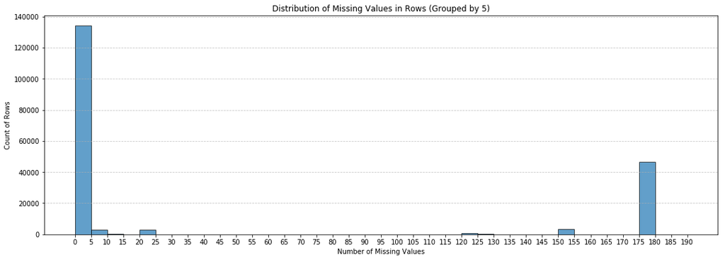

```python
# visualize results

c_nan_distr = customers['NaN Count Raw'].value_counts().sort_index()

bins = np.arange(0, c_nan_distr.index.max() + 5, 5)

# Create a bar chart with custom bins
plt.figure(figsize=(18, 6))
plt.hist(customers['NaN Count Raw'], bins=bins, edgecolor='k', alpha=0.7)
plt.xticks(bins)
plt.xlabel('Number of Missing Values')
plt.ylabel('Count of Rows')
plt.title('Distribution of Missing Values in Rows (Grouped by 5)')
plt.grid(axis='y', linestyle='--', alpha=0.7)
plt.show()
```

```python
# divide the data into two subsets based on the number of missing values in each row

#using 5 NaN values as the threshold for the groups
threshold = 5

azdias_sub5 = azdias[azdias['NaN Count Raw'] <= threshold]
azdias_over5 = azdias[azdias['NaN Count Raw'] > threshold]

cust_sub5 = customers[customers['NaN Count Raw'] <= threshold]
cust_over5 = customers[customers['NaN Count Raw'] > threshold]
```

I am also going to remove records with more than 5 records missing so that I can use as complete a dataset as possible for informing my model later on

```python
cust_sub5.to_csv('cust_sub5.csv', index=False)
```

```python
azdias_over5.head(5)
```

|  | AGER_TYP | ALTER_HH | ANZ_HAUSHALTE_AKTIV | ANZ_HH_TITEL | ANZ_PERSONEN | ANZ_TITEL | BALLRAUM | CAMEO_DEU_2015 | CAMEO_DEUG_2015 | CJT_GESAMTTYP | ... | SHOPPER_TYP | TITEL_KZ | VERS_TYP | W_KEIT_KIND_HH | WOHNDAUER_2008 | WOHNLAGE | ZABEOTYP | ANREDE_KZ | ALTERSKATEGORIE_GROB | NaN Count Raw |
| --- | --- | --- | --- | --- | --- | --- | --- | --- | --- | --- | --- | --- | --- | --- | --- | --- | --- | --- | --- | --- | --- |
| 0 | -1 | NaN | NaN | NaN | NaN | NaN | NaN | NaN | NaN | 2.0 | ... | -1 | NaN | -1 | NaN | NaN | NaN | 3 | 1 | 2 | 203 |
| 11 | -1 | NaN | NaN | NaN | NaN | NaN | NaN | NaN | NaN | 6.0 | ... | -1 | NaN | -1 | NaN | NaN | NaN | 3 | 1 | 2 | 203 |
| 12 | -1 | 21.0 | 1.0 | 0.0 | 2.0 | 0.0 | 2.0 | 6B | 6 | 6.0 | ... | 1 | 0.0 | 1 | 6.0 | 4.0 | 3.0 | 1 | 1 | 3 | 64 |
| 13 | -1 | 20.0 | 2.0 | 0.0 | 1.0 | 0.0 | 7.0 | 5C | 5 | 5.0 | ... | 3 | 0.0 | 2 | 6.0 | 3.0 | 5.0 | 5 | 2 | 1 | 66 |
| 14 | -1 | NaN | NaN | NaN | NaN | NaN | NaN | NaN | NaN | 6.0 | ... | -1 | NaN | -1 | NaN | NaN | NaN | 3 | 1 | 3 | 203 |

5 rows × 269 columns

```python
cust_over5.head(5)
```

|  | LNR | AGER_TYP | AKT_DAT_KL | ALTER_HH | ALTERSKATEGORIE_FEIN | ANZ_HAUSHALTE_AKTIV | ANZ_HH_TITEL | ANZ_KINDER | ANZ_PERSONEN | ANZ_STATISTISCHE_HAUSHALTE | ... | VK_ZG11 | WOHNDAUER_2008 | WOHNLAGE | ZABEOTYP | PRODUCT_GROUP | CUSTOMER_GROUP | ONLINE_PURCHASE | ANREDE_KZ | ALTERSKATEGORIE_GROB | NaN Count Raw |
| --- | --- | --- | --- | --- | --- | --- | --- | --- | --- | --- | --- | --- | --- | --- | --- | --- | --- | --- | --- | --- | --- |
| 1 | 9628 | -1 | 9.0 | 11.0 | NaN | NaN | NaN | 0.0 | 3.0 | NaN | ... | 3.0 | 9.0 | NaN | 3 | FOOD | SINGLE_BUYER | 0 | 1 | 4 | 174 |
| 10 | 102184 | -1 | 7.0 | 14.0 | 14.0 | NaN | NaN | 0.0 | 1.0 | NaN | ... | 7.0 | 3.0 | NaN | 3 | COSMETIC | MULTI_BUYER | 1 | 2 | 3 | 153 |
| 23 | 110344 | -1 | 7.0 | 14.0 | 14.0 | 45.0 | 0.0 | 0.0 | 1.0 | 41.0 | ... | 7.0 | 7.0 | 4.0 | 6 | COSMETIC | SINGLE_BUYER | 1 | 1 | 3 | 9 |
| 36 | 125534 | -1 | NaN | NaN | NaN | NaN | NaN | NaN | NaN | NaN | ... | NaN | NaN | NaN | 3 | FOOD | MULTI_BUYER | 0 | 2 | 1 | 178 |
| 37 | 125535 | -1 | NaN | NaN | NaN | NaN | NaN | NaN | NaN | NaN | ... | NaN | NaN | NaN | 3 | FOOD | SINGLE_BUYER | 0 | 2 | 3 | 178 |

5 rows × 295 columns

```python
azdias_sub5.shape
```

```
(743322, 269)
```

### Re-encoding of features

```python
#check datatypes of each column to figure out which ones we need to analyze further
for column in azdias_sub5.columns:
    print(f"Column '{column}' has datatype: {azdias_sub5[column].dtype}")
```

```
Column 'AGER_TYP' has datatype: int64
Column 'ALTER_HH' has datatype: float64
Column 'ANZ_HAUSHALTE_AKTIV' has datatype: float64
Column 'ANZ_HH_TITEL' has datatype: float64
Column 'ANZ_PERSONEN' has datatype: float64
Column 'ANZ_TITEL' has datatype: float64
Column 'BALLRAUM' has datatype: float64
Column 'CAMEO_DEU_2015' has datatype: object
Column 'CAMEO_DEUG_2015' has datatype: object
Column 'CJT_GESAMTTYP' has datatype: float64
Column 'D19_BANKEN_ANZ_12' has datatype: int64
Column 'D19_BANKEN_ANZ_24' has datatype: int64
Column 'D19_BANKEN_DATUM' has datatype: int64
Column 'D19_BANKEN_OFFLINE_DATUM' has datatype: int64
Column 'D19_BANKEN_ONLINE_DATUM' has datatype: int64
Column 'D19_GESAMT_ANZ_12' has datatype: int64
Column 'D19_GESAMT_ANZ_24' has datatype: int64
Column 'D19_GESAMT_DATUM' has datatype: int64
Column 'D19_GESAMT_OFFLINE_DATUM' has datatype: int64
Column 'D19_GESAMT_ONLINE_DATUM' has datatype: int64
Column 'D19_TELKO_ANZ_12' has datatype: int64
Column 'D19_TELKO_ANZ_24' has datatype: int64
Column 'D19_TELKO_DATUM' has datatype: int64
Column 'D19_TELKO_OFFLINE_DATUM' has datatype: int64
Column 'D19_TELKO_ONLINE_DATUM' has datatype: int64
Column 'D19_VERSAND_ANZ_12' has datatype: int64
Column 'D19_VERSAND_ANZ_24' has datatype: int64
Column 'D19_VERSAND_DATUM' has datatype: int64
Column 'D19_VERSAND_OFFLINE_DATUM' has datatype: int64
Column 'D19_VERSAND_ONLINE_DATUM' has datatype: int64
Column 'D19_VERSI_ANZ_12' has datatype: int64
Column 'D19_VERSI_ANZ_24' has datatype: int64
Column 'EWDICHTE' has datatype: float64
Column 'FINANZ_ANLEGER' has datatype: int64
Column 'FINANZ_HAUSBAUER' has datatype: int64
Column 'FINANZ_MINIMALIST' has datatype: int64
Column 'FINANZ_SPARER' has datatype: int64
Column 'FINANZ_UNAUFFAELLIGER' has datatype: int64
Column 'FINANZ_VORSORGER' has datatype: int64
Column 'FINANZTYP' has datatype: int64
```

[output cut: 214 more lines]

```
Column 'SEMIO_RAT' has datatype: int64
Column 'SEMIO_REL' has datatype: int64
Column 'SEMIO_SOZ' has datatype: int64
Column 'SEMIO_TRADV' has datatype: int64
Column 'SEMIO_VERT' has datatype: int64
Column 'SHOPPER_TYP' has datatype: int64
Column 'TITEL_KZ' has datatype: float64
Column 'VERS_TYP' has datatype: int64
Column 'W_KEIT_KIND_HH' has datatype: float64
Column 'WOHNDAUER_2008' has datatype: float64
Column 'WOHNLAGE' has datatype: float64
Column 'ZABEOTYP' has datatype: int64
Column 'ANREDE_KZ' has datatype: int64
Column 'ALTERSKATEGORIE_GROB' has datatype: int64
Column 'NaN Count Raw' has datatype: int64
```

```python
datatype_counts = azdias_sub5.dtypes.value_counts()

# Print each unique datatype and the count
for datatype, count in datatype_counts.items():
    print(f"Datatype '{datatype}' has {count} columns.")
```

```
Datatype 'float64' has 211 columns.
Datatype 'int64' has 55 columns.
Datatype 'object' has 3 columns.
```

```python
object_columns = azdias_sub5.select_dtypes(include=['object']).columns

# Print the names of object columns
print("Columns with datatype 'object':")
for column in object_columns:
    print(column)
```

```
Columns with datatype 'object':
CAMEO_DEU_2015
CAMEO_DEUG_2015
OST_WEST_KZ
```

```python
for column in azdias_sub5.columns:
    unique_values = azdias_sub5[column].unique()
    print(f"Column: {column}")
    for value in unique_values:
        print(value)
    print("\n")
```

[output not shown]

[output cut: 4160 more lines]

```
Column: ALTERSKATEGORIE_GROB
1
3
4
2
9


Column: NaN Count Raw
0
1
4
2
3
5
```

Most of the columns are either float or integers so we can leave them as is. However, the 3 object columns will need to be re-encoded. There are two other columns that have years that will also need to be re-encoded

```python
# object fields to be re-encoded
print(azdias_sub5['CAMEO_DEU_2015'].unique())
print(azdias_sub5['CAMEO_DEUG_2015'].unique())
print(azdias_sub5['OST_WEST_KZ'].unique())

# years to be re-encoded
print(azdias_sub5['GEBURTSJAHR'].unique())
print(azdias_sub5['MIN_GEBAEUDEJAHR'].unique())
```

```
['8A' '4C' '2A' '6B' '8C' '4A' '2D' '1A' '1E' '9D' '7A' '5D' '9E' '5C' '9B'
 '1B' '8B' '3D' nan '4E' '4B' '3C' '5A' '7B' '9A' '6D' '6E' '2C' '7C' '9C'
 '7D' '5E' '1D' '8D' '6C' '6A' '5B' '4D' '3A' '2B' '7E' '3B' '6F' '5F' '1C'
 'XX']
[8.0 4.0 2.0 6.0 1.0 9.0 7.0 5.0 3.0 nan '3' '7' '2' '4' '8' '9' '6' '5'
 '1' 'X']
['W' 'O']
[1996 1979 1957 1963 1943    0 1964 1974 1975 1941 1988 1991 1966 1949 1982
 1972 1990 1985 1989 1948 1935 1997 1994 1987 2002 1950 1978 1958 1944 1967
 1977 1960 1970 1973 1971 1937 1947 1926 1954 1946 1981 1962 1992 2008 1965
 1976 1928 1927 1940 1952 1961 1938 1945 1942 1968 1984 1930 1980 2006 1959
 1986 1931 1993 1955 1983 2010 1951 1921 1929 1939 2001 1995 1956 1953 1969
 2012 1934 1913 1914 2004 1936 2009 2003 2013 1998 2007 1932 2005 1923 1925
 1933 2017 2000 1999 2014 1920 1922 1924 2016 2015 2011 1918 1915 1919 1916
 1917 1912 1911 1909 1910 1904 1906 1905 1908 1900 1907]
[ 1992.  1997.  1994.  1996.  1991.  1993.  1995.  2003.  2000.  1990.
  2004.  1999.  1998.  2001.  2002.  1989.  1987.  1988.  2005.  1985.
  1986.]
```

Upon further exploration we can see what each of these columns describes:

- CAMEO_DEU_2015: CAMEO classification 2015 - detailled classification
- CAMEO_DEUG_2015:CAMEO classification 2015 - Uppergroup
- OST_WEST_KZ: flag indicating the former GDR/FRG
- GEBURTSJAHR: year of birth
- MIN_GEBAEUDEJAHR: year the building was first mentioned in our database

```python
# Drop fields for years and also CAMEO_DEU_2015 due to too many unique variables
azdias_sub5 = azdias_sub5.drop(['GEBURTSJAHR', 'MIN_GEBAEUDEJAHR', 'CAMEO_DEU_2015'], axis=1)
```

```python
# Re-encode OST_WEST_KZ
azdias_sub5.loc[:, 'OST_WEST_KZ'].replace({'W': 0, 'O': 1}, inplace=True)

# Re-encode CAMEO_DEUG_2015 to replace nan/X nad convert everything into integers
azdias_sub5['CAMEO_DEUG_2015'].replace({'X': -1, np.nan: -1, '8.0': 8, '4.0': 4, '2.0': 2, '6.0': 6, '1.0': 1, '9.0': 9, '7.0': 7, '5.0': 5, '3.0': 3, '3': 3, '8': 8, '5': 5, '4': 4, '9': 9, '6': 6, '7': 7, '2': 2, '1': 1}, inplace=True)
```

```python
print(azdias_sub5['CAMEO_DEUG_2015'].unique())
print(azdias_sub5['OST_WEST_KZ'].unique())
```

```
[ 8.  4.  2.  6.  1.  9.  7.  5.  3. -1.]
[0 1]
```

To avoid multi-collinearity with the sheer volumn of features, we are going to quickly see if any are highly correlated and remove any as needed

[figure not shown]

```python
correlation_matrix = azdias_sub5.corr()
plt.figure(figsize=(12, 10))
sns.heatmap(correlation_matrix, annot=True, cmap="coolwarm", fmt=".2f")
plt.show()
```

```python
threshold = 0.85
# Create a set to store columns to drop
columns_to_drop = set()

# Find correlated pairs and add one column to the set of columns to drop
for i in range(len(correlation_matrix.columns)):
    for j in range(i):
        if abs(correlation_matrix.iloc[i, j]) > threshold:
            # Add one of the columns to the set (choose which one to keep)
            columns_to_drop.add(correlation_matrix.columns[j])
```

```python
columns_to_drop
```

```
{'D19_BANKEN_DATUM',
 'D19_GESAMT_ANZ_12',
 'D19_GESAMT_ANZ_24',
 'D19_GESAMT_DATUM',
 'D19_GESAMT_ONLINE_DATUM',
 'D19_VERSAND_ANZ_12',
 'D19_VERSAND_ANZ_24',
 'D19_VERSAND_DATUM',
 'KBA05_AUTOQUOT',
 'KBA05_HERST1',
 'KBA05_HERST2',
 'KBA05_HERST3',
 'KBA05_KRSKLEIN',
 'KBA05_KRSOBER',
 'KBA05_KRSVAN',
 'KBA05_KRSZUL',
 'KBA05_MOD8',
 'KBA13_ALTERHALTER_45',
 'KBA13_ALTERHALTER_60',
 'KBA13_ALTERHALTER_61',
 'KBA13_FAB_SONSTIGE',
 'KBA13_HERST_AUDI_VW',
 'KBA13_KMH_211',
 'KBA13_SITZE_4',
 'LP_FAMILIE_FEIN',
 'LP_FAMILIE_GROB',
 'LP_LEBENSPHASE_FEIN',
 'LP_STATUS_FEIN',
 'SEMIO_KAEM',
 'SEMIO_VERT'}
```

```python
azdias_sub5 = azdias_sub5.drop(columns=list(columns_to_drop))
```

Repeat for Customers DF

```python
# drop any columns the azdias_sub5 and cust_sub5 don't have in common
columns_to_drop = [col for col in cust_sub5.columns if col not in azdias_sub5.columns]

# drop the columns from cust_sub5
cust_sub5 = cust_sub5.drop(columns=columns_to_drop)
```

```python
datatype_counts = cust_sub5.dtypes.value_counts()

# Print each unique datatype and the count
for datatype, count in datatype_counts.items():
    print(f"Datatype '{datatype}' has {count} columns.")
```

```
Datatype 'float64' has 132 columns.
Datatype 'int64' has 44 columns.
Datatype 'object' has 2 columns.
```

```python
object_columns = cust_sub5.select_dtypes(include=['object']).columns

# Print the names of object columns
print("Columns with datatype 'object':")
for column in object_columns:
    print(column)
```

```
Columns with datatype 'object':
CAMEO_DEUG_2015
OST_WEST_KZ
```

```python
# Re-encode OST_WEST_KZ
cust_sub5.loc[:, 'OST_WEST_KZ'].replace({'W': 0, 'O': 1}, inplace=True)

# Re-encode CAMEO_DEUG_2015 to replace nan/X nad convert everything into integers
cust_sub5['CAMEO_DEUG_2015'].replace({'X': -1, np.nan: -1, '8.0': 8, '4.0': 4, '2.0': 2, '6.0': 6, '1.0': 1, '9.0': 9, '7.0': 7, '5.0': 5, '3.0': 3}, inplace=True)
```

```python
# Re-encode OST_WEST_KZ
cust_sub5.loc[:, 'OST_WEST_KZ'].replace({'W': 0, 'O': 1}, inplace=True)

# Re-encode CAMEO_DEUG_2015 to replace nan/X nad convert everything into integers
cust_sub5['CAMEO_DEUG_2015'].replace({'X': -1, np.nan: -1, '8.0': 8, '4.0': 4, '2.0': 2, '6.0': 6, '1.0': 1, '9.0': 9, '7.0': 7, '5.0': 5, '3.0': 3}, inplace=True)
cust_sub5['CAMEO_DEUG_2015'].replace({'X': -1, np.nan: -1, '8.0': 8, '4.0': 4, '2.0': 2, '6.0': 6, '1.0': 1, '9.0': 9, '7.0': 7, '5.0': 5, '3.0': 3, '3': 3, '8': 8, '5': 5, '4': 4, '9': 9, '6': 6, '7': 7, '2': 2, '1': 1}, inplace=True)
```

```python
print(cust_sub5['CAMEO_DEUG_2015'].unique())
print(cust_sub5['OST_WEST_KZ'].unique())
```

```
[ 1.  5.  4.  7.  3.  9.  2.  6.  8. -1.]
[0 1]
```

```python
correlation_matrix = cust_sub5.corr()
threshold = 0.85
# Create a set to store columns to drop
columns_to_drop = set()

# Find correlated pairs and add one column to the set of columns to drop
for i in range(len(correlation_matrix.columns)):
    for j in range(i):
        if abs(correlation_matrix.iloc[i, j]) > threshold:
            # Add one of the columns to the set (choose which one to keep)
            columns_to_drop.add(correlation_matrix.columns[j])
```

```python
columns_to_drop
```

```
{'D19_GESAMT_OFFLINE_DATUM', 'FINANZ_SPARER'}
```

```python
cust_sub5 = cust_sub5.drop(columns=list(columns_to_drop))
```

### Evaluate NaNs

```python
azdias_sub5.isnull().sum().sort_values(ascending=False)
```

```
W_KEIT_KIND_HH              31328
KKK                          7190
REGIOTYP                     7190
ORTSGR_KLS9                  3881
RELAT_AB                     3881
ANZ_HH_TITEL                 3302
BALLRAUM                      516
INNENSTADT                    516
EWDICHTE                      516
KONSUMNAEHE                    47
GEBAEUDETYP_RASTER              5
NaN Count Raw                   0
KBA05_SEG2                      0
KBA05_SEG10                     0
KBA05_SEG4                      0
KBA05_SEG3                      0
KBA05_MOTRAD                    0
KBA05_SEG5                      0
KBA05_SEG6                      0
KBA05_SEG1                      0
KBA05_MODTEMP                   0
KBA05_MOTOR                     0
KBA05_MOD4                      0
KBA05_MOD3                      0
KBA05_MOD2                      0
KBA05_MOD1                      0
KBA05_MAXVORB                   0
KBA05_MAXSEG                    0
KBA05_MAXHERST                  0
KBA05_MAXBJ                     0
                            ...
ALTERSKATEGORIE_GROB            0
KBA13_KMH_251                   0
KBA13_KRSAQUOT                  0
KBA13_KRSHERST_AUDI_VW          0
KBA13_KW_60                     0
KBA13_RENAULT                   0
KBA13_PEUGEOT                   0
KBA13_OPEL                      0
KBA13_NISSAN                    0
KBA13_MOTOR                     0
KBA13_MERCEDES                  0
KBA13_MAZDA                     0
KBA13_KW_90                     0
KBA13_KW_80                     0
KBA13_KW_70                     0
KBA13_KW_61_120                 0
KBA13_KW_50                     0
KBA13_KRSHERST_BMW_BENZ         0
KBA13_KW_40                     0
KBA13_KW_30                     0
KBA13_KW_121                    0
KBA13_KW_120                    0
KBA13_KW_110                    0
KBA13_KW_0_60                   0
KBA13_KRSZUL_NEU                0
KBA13_KRSSEG_VAN                0
KBA13_KRSSEG_OBER               0
KBA13_KRSSEG_KLEIN              0
KBA13_KRSHERST_FORD_OPEL        0
AGER_TYP                        0
Length: 236, dtype: int64
```

```python
# drop W_KEIT_KIND_HH due to having too many null values
azdias_sub5.drop(['W_KEIT_KIND_HH'], axis=1, inplace=True)
```

```python
azdias_sub5.isnull().sum().sum()
```

```
27044
```

```python
azdias_sub5.fillna(method='ffill', inplace=True)
azdias_sub5.fillna(method='bfill', inplace=True)

azdias_sub5.isnull().sum().sum()
```

```
0
```

With such a large dataset, there really aren't a ton of NaN values but we are going to use a combination of forward and back filling to impute the missing datapoints ahead of training our unsupervised model

```python
azdias_sub5.to_csv('azdias_sub5.csv', index=False)
```

```python
cust_sub5.isnull().sum().sort_values(ascending=False)
```

```
ANZ_HH_TITEL                   2028
EWDICHTE                         30
BALLRAUM                         30
INNENSTADT                       30
KONSUMNAEHE                       5
KBA13_BMW                         0
KBA13_CCM_2000                    0
KBA13_FORD                        0
KBA13_FIAT                        0
KBA13_FAB_ASIEN                   0
KBA13_CCM_3001                    0
KBA13_CCM_3000                    0
KBA13_CCM_2501                    0
KBA13_CCM_2500                    0
KBA13_CCM_1800                    0
KBA13_CCM_0_1400                  0
KBA13_CCM_1600                    0
KBA13_HALTER_25                   0
KBA13_CCM_1500                    0
KBA13_CCM_1400                    0
KBA13_CCM_1200                    0
KBA13_BJ_2009                     0
KBA13_CCM_1000                    0
KBA13_HALTER_20                   0
NaN Count Raw                     0
KBA13_BJ_2006                     0
KBA13_HERST_BMW_BENZ              0
KBA13_KMH_180                     0
KBA13_KMH_140_210                 0
KBA13_KMH_140                     0
                               ...
KBA13_KW_0_60                     0
KBA13_KRSZUL_NEU                  0
KBA13_KRSSEG_VAN                  0
KBA13_KRSSEG_OBER                 0
KBA13_KRSSEG_KLEIN                0
KBA13_KRSHERST_FORD_OPEL          0
KBA13_KRSHERST_BMW_BENZ           0
KBA13_MAZDA                       0
KBA13_MOTOR                       0
KBA13_SITZE_5                     0
KBA13_SEG_MINIWAGEN               0
KBA13_SEG_WOHNMOBILE              0
KBA13_SEG_VAN                     0
KBA13_SEG_UTILITIES               0
KBA13_SEG_SPORTWAGEN              0
KBA13_SEG_SONSTIGE                0
KBA13_SEG_OBERKLASSE              0
KBA13_SEG_OBEREMITTELKLASSE       0
KBA13_SEG_MITTELKLASSE            0
KBA13_SEG_MINIVANS                0
KBA13_NISSAN                      0
KBA13_SEG_KOMPAKTKLASSE           0
KBA13_SEG_KLEINWAGEN              0
KBA13_SEG_KLEINST                 0
KBA13_SEG_GROSSRAUMVANS           0
KBA13_SEG_GELAENDEWAGEN           0
KBA13_RENAULT                     0
KBA13_PEUGEOT                     0
KBA13_OPEL                        0
AGER_TYP                          0
Length: 176, dtype: int64
```

```python
cust_sub5.fillna(method='ffill', inplace=True)
cust_sub5.fillna(method='bfill', inplace=True)

cust_sub5.isnull().sum().sum()
```

```
0
```

```python
cust_sub5.to_csv('cust_sub5.csv', index=False)
```

Scale Features

```python
scaler = StandardScaler()
azdias_sub5_scaled = scaler.fit_transform(azdias_sub5)
cust_sub5_scaled = scaler.fit_transform(cust_sub5)
azdias_sub5_scaled = pd.DataFrame(azdias_sub5_scaled, columns=azdias_sub5.columns)
cust_sub5_scaled = pd.DataFrame(cust_sub5_scaled, columns=cust_sub5.columns)
print("Done")
```

```
Done
```

I am also applied a StandardScaler to make sure that all the features (columns) in my data have the same scale or "units." This is important because some algorithms can be sensitive to the scale of your data.

```python
print(azdias_sub5_scaled.shape)
print(cust_sub5_scaled.shape)
```

```
(743322, 235)
(134248, 176)
```

```python
azdias_sub5_scaled = pd.read_csv('azdias_sub5_scaled.csv')
cust_sub5_scaled = pd.read_csv('cust_sub5_scaled.csv')
```

## Part 1: Customer Segmentation Report

The main bulk of your analysis will come in this part of the project. Here, you should use unsupervised learning techniques to describe the relationship between the demographics of the company's existing customers and the general population of Germany. By the end of this part, you should be able to describe parts of the general population that are more likely to be part of the mail-order company's main customer base, and which parts of the general population are less so.

### Apply feature scaling and reduce dimensionality

```python
pca = PCA()
azdias_pca = pca.fit_transform(azdias_sub5_scaled)
```

I am also applying Principal Component Analysis. PCA is a statistical technique used for dimensionality reduction with a primary goal of simplifying complex data while retaining trends and patterns.

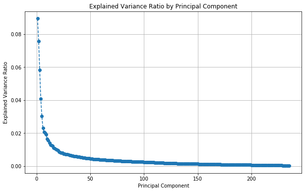

```python
# Investigate the variance accounted for by each principal component.
var1a = pca.explained_variance_ratio_

plt.figure(figsize=(10, 6))
plt.plot(range(1, len(var1a) + 1), var1a, marker='o', linestyle='--')
plt.title('Explained Variance Ratio by Principal Component')
plt.xlabel('Principal Component')
plt.ylabel('Explained Variance Ratio')
plt.grid(True)
plt.show()
```

Here we see that there is a substantial drop in explained variance around the 25 component mark but with a goal of getting north of 85% explained variance, I am goin to test different n_components between 50-150 until I am able to cross that threshold

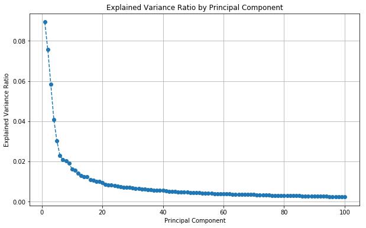

```
Sum of variances for 100 components is 85.72%
```

```python
# Re-apply PCA to the data while selecting for number of components to retain.

n_components = 100
var1b = pca.explained_variance_ratio_[:n_components]


plt.figure(figsize=(10, 6))
plt.plot(range(1, len(var1b) + 1), var1b, marker='o', linestyle='--')
plt.title('Explained Variance Ratio by Principal Component')
plt.xlabel('Principal Component')
plt.ylabel('Explained Variance Ratio')
plt.grid(True)
plt.show()


print('Sum of variances for {} components is {:.2f}%'.format(n_components, np.sum(var1b)*100))
```

```python
pca2 = PCA()
cust_pca = pca2.fit_transform(cust_sub5_scaled)
```

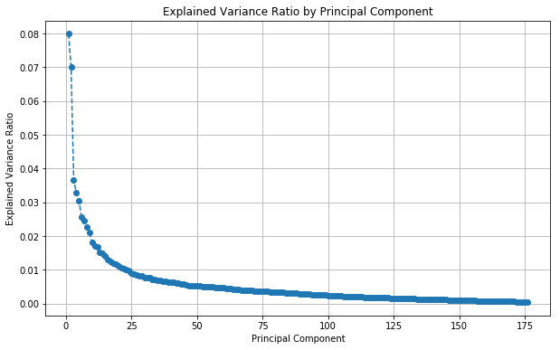

```python
var2a = pca2.explained_variance_ratio_

plt.figure(figsize=(10, 6))
plt.plot(range(1, len(var2a) + 1), var2a, marker='o', linestyle='--')
plt.title('Explained Variance Ratio by Principal Component')
plt.xlabel('Principal Component')
plt.ylabel('Explained Variance Ratio')
plt.grid(True)
plt.show()
```

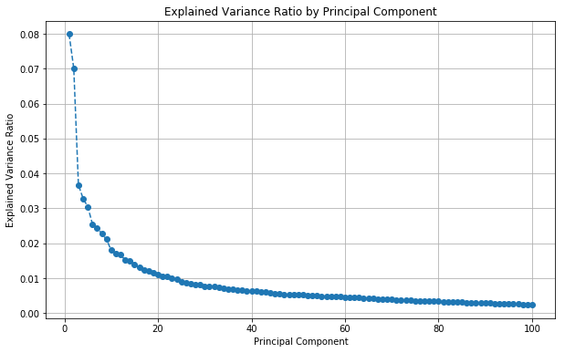

```
Sum of variances for 100 components is 90.13%
```

```python
# Re-apply PCA to the data while selecting for number of components to retain.

n_components = 100
var2b = pca2.explained_variance_ratio_[:n_components]


plt.figure(figsize=(10, 6))
plt.plot(range(1, len(var2b) + 1), var2b, marker='o', linestyle='--')
plt.title('Explained Variance Ratio by Principal Component')
plt.xlabel('Principal Component')
plt.ylabel('Explained Variance Ratio')
plt.grid(True)
plt.show()


print('Sum of variances for {} components is {:.2f}%'.format(n_components, np.sum(var2b)*100))
```

### Based on what I am seeing above, 100 is a reasonable number of variables to reduce both dataframes to and still explain 85%+ of the varability in the output

```python
pca = PCA(n_components=100)
```

```python
azdias_pca_100 = pca.fit_transform(azdias_sub5_scaled)
azdias_pca_100 = pd.DataFrame(azdias_pca_100)
```

```python
cust_pca_100 = pca.fit_transform(cust_sub5_scaled)
cust_pca_100 = pd.DataFrame(cust_pca_100)
```

```python
azdias_pca_100.to_csv('azdias_pca_100.csv', index=False)
cust_pca_100.to_csv('cust_pca_100.csv', index=False)
```

```python
azdias_pca_100 = pd.read_csv('azdias_pca_100.csv')
cust_pca_100 = pd.read_csv('cust_pca_100.csv')
```

```python
print(azdias_pca_100.shape)
print(cust_pca_100.shape)
```

```
(743322, 100)
(134248, 100)
```

Apply K Clustering - the primary goal of this is to partition a dataset into distinct, non-overlapping subgroups, or clusters. By doing so we can identify patterns, compress our data, identify anomolies and make better inferences about our data

```python
import datetime

wcss = []

c_count = range(1, 21, 2)

for c in c_count:
    print('Starting for c: {}: {}'.format(c,datetime.datetime.now()))
    kmeans = KMeans(n_clusters=c, random_state=0)
    kmeans.fit(azdias_pca_100)
    wcss.append(kmeans.inertia_)

print('All clusters complete')
```

```
Starting for c: 1: 2023-10-16 23:59:52.365600
Starting for c: 3: 2023-10-17 00:01:33.754332
Starting for c: 5: 2023-10-17 00:02:23.192256
Starting for c: 7: 2023-10-17 00:03:47.673270
Starting for c: 9: 2023-10-17 00:05:50.859669
Starting for c: 11: 2023-10-17 00:08:46.576877
Starting for c: 13: 2023-10-17 00:12:57.980092
Starting for c: 15: 2023-10-17 00:17:35.414518
Starting for c: 17: 2023-10-17 00:22:26.648710
Starting for c: 19: 2023-10-17 00:27:35.123323
All clusters complete
```

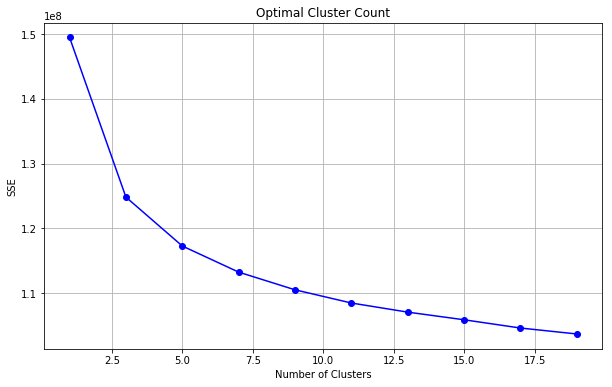

```python
# Use matplotlib's plot function to visualize this relationship.

plt.figure(figsize=(10, 6))
plt.plot(c_count, wcss, marker='o', linestyle='-', color='b')
plt.xlabel('Number of Clusters')
plt.ylabel('SSE')
plt.title('Optimal Cluster Count')
plt.grid(True)
plt.show()
```

```python
# Re-fit the k-means model with the selected number of clusters and obtain
# cluster predictions for the general population demographics data.
kmeans = KMeans(n_clusters=9)
kmeans = kmeans.fit(azdias_pca_100)
adzias_predictions = kmeans.predict(azdias_pca_100)
```

```python
display(adzias_predictions)
```

```
array([5, 8, 2, ..., 5, 7, 2], dtype=int32)
```

```python
cust_kmeans = kmeans.fit(cust_pca_100)
cust_predictions = kmeans.predict(cust_pca_100)
display(cust_predictions)
```

```
array([7, 0, 7, ..., 7, 5, 4], dtype=int32)
```

```python
adzias_cluster = pd.DataFrame(adzias_predictions)
cust_cluster = pd.DataFrame(cust_predictions)
adzias_cluster = adzias_cluster.rename(columns={adzias_cluster.columns[0]: 'Kmeans_Cluster'})
cust_cluster = cust_cluster.rename(columns={cust_cluster.columns[0]: 'Kmeans_Cluster'})
```

```python
adzias_cluster.to_csv('adzias_cluster.csv', index=False)
cust_cluster.to_csv('cust_cluster.csv', index=False)
```

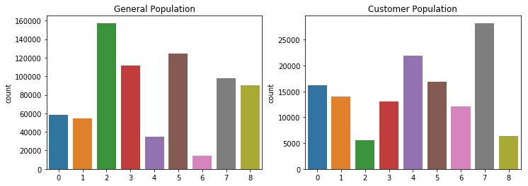

```python
# Compare the proportion of data in each cluster for the customer data to the
# proportion of data in each cluster for the general population.

fig = plt.figure(figsize=(12,4))
ax1 = fig.add_subplot(121)
ax1.title.set_text('General Population')
sns.countplot(adzias_predictions)
#ax1.set_ylim(0, 81000)

ax2 = fig.add_subplot(122)
ax2.title.set_text('Customer Population')
sns.countplot(cust_predictions)
#ax2.set_ylim(0, 81000)

plt.show()
```

This is interesting because we are seeing a few major differences after clustering our data between the general population and customer population. Most notably, cluster_2 is severely underrepresented in the customer population, while cluster_4 and cluster_7 has significantly higher representation in the customer population.

```python
adzias_cluster = pd.read_csv('adzias_cluster.csv')
cust_cluster = pd.read_csv('cust_cluster.csv')
```

## Part 2: Supervised Learning Model

Now that you've found which parts of the population are more likely to be customers of the mail-order company, it's time to build a prediction model. Each of the rows in the "MAILOUT" data files represents an individual that was targeted for a mailout campaign. Ideally, we should be able to use the demographic information from each individual to decide whether or not it will be worth it to include that person in the campaign.

The "MAILOUT" data has been split into two approximately equal parts, each with almost 43 000 data rows. In this part, you can verify your model with the "TRAIN" partition, which includes a column, "RESPONSE", that states whether or not a person became a customer of the company following the campaign. In the next part, you'll need to create predictions on the "TEST" partition, where the "RESPONSE" column has been withheld.

```python
mailout_train = pd.read_csv('../../data/Term2/capstone/arvato_data/Udacity_MAILOUT_052018_TRAIN.csv', sep=';')
mailout_train.head(5)
```

|  | LNR | AGER_TYP | AKT_DAT_KL | ALTER_HH | ALTER_KIND1 | ALTER_KIND2 | ALTER_KIND3 | ALTER_KIND4 | ALTERSKATEGORIE_FEIN | ANZ_HAUSHALTE_AKTIV | ... | VK_DHT4A | VK_DISTANZ | VK_ZG11 | W_KEIT_KIND_HH | WOHNDAUER_2008 | WOHNLAGE | ZABEOTYP | RESPONSE | ANREDE_KZ | ALTERSKATEGORIE_GROB |
| --- | --- | --- | --- | --- | --- | --- | --- | --- | --- | --- | --- | --- | --- | --- | --- | --- | --- | --- | --- | --- | --- |
| 0 | 1763 | 2 | 1.0 | 8.0 | NaN | NaN | NaN | NaN | 8.0 | 15.0 | ... | 5.0 | 2.0 | 1.0 | 6.0 | 9.0 | 3.0 | 3 | 0 | 2 | 4 |
| 1 | 1771 | 1 | 4.0 | 13.0 | NaN | NaN | NaN | NaN | 13.0 | 1.0 | ... | 1.0 | 2.0 | 1.0 | 4.0 | 9.0 | 7.0 | 1 | 0 | 2 | 3 |
| 2 | 1776 | 1 | 1.0 | 9.0 | NaN | NaN | NaN | NaN | 7.0 | 0.0 | ... | 6.0 | 4.0 | 2.0 | NaN | 9.0 | 2.0 | 3 | 0 | 1 | 4 |
| 3 | 1460 | 2 | 1.0 | 6.0 | NaN | NaN | NaN | NaN | 6.0 | 4.0 | ... | 8.0 | 11.0 | 11.0 | 6.0 | 9.0 | 1.0 | 3 | 0 | 2 | 4 |
| 4 | 1783 | 2 | 1.0 | 9.0 | NaN | NaN | NaN | NaN | 9.0 | 53.0 | ... | 2.0 | 2.0 | 1.0 | 6.0 | 9.0 | 3.0 | 3 | 0 | 1 | 3 |

5 rows × 367 columns

```python
counts = mailout_train['RESPONSE'].value_counts()
counts
```

```
0    42430
1      532
Name: RESPONSE, dtype: int64
```

Only 1% of the population has a response equal to 1, leading to a very skewed dataset to work with

```python
from sklearn.utils import resample

yes_cust = mailout_train[mailout_train['RESPONSE']==1]
no_cust = mailout_train[mailout_train['RESPONSE']==0]
yes_balanced = resample(yes_cust, replace=True, n_samples=42430, random_state=1)
yes_balanced.describe()
```

|  | LNR | AGER_TYP | AKT_DAT_KL | ALTER_HH | ALTER_KIND1 | ALTER_KIND2 | ALTER_KIND3 | ALTER_KIND4 | ALTERSKATEGORIE_FEIN | ANZ_HAUSHALTE_AKTIV | ... | VK_DHT4A | VK_DISTANZ | VK_ZG11 | W_KEIT_KIND_HH | WOHNDAUER_2008 | WOHNLAGE | ZABEOTYP | RESPONSE | ANREDE_KZ | ALTERSKATEGORIE_GROB |
| --- | --- | --- | --- | --- | --- | --- | --- | --- | --- | --- | --- | --- | --- | --- | --- | --- | --- | --- | --- | --- | --- |
| count | 42430.000000 | 42430.00000 | 35812.000000 | 35812.000000 | 1729.000000 | 797.000000 | 323.000000 | 80.0 | 34605.000000 | 34976.000000 | ... | 35565.000000 | 35565.000000 | 35565.000000 | 34385.000000 | 35812.000000 | 34976.000000 | 42430.000000 | 42430.0 | 42430.000000 | 42430.000000 |
| mean | 42055.047066 | 0.70865 | 1.296912 | 9.497906 | 13.068826 | 13.265997 | 15.049536 | 10.0 | 9.339835 | 5.783966 | ... | 4.203430 | 4.251343 | 2.875524 | 4.681605 | 8.803753 | 4.121655 | 2.675725 | 1.0 | 1.562314 | 3.248221 |
| std | 24216.936957 | 1.38789 | 1.370879 | 5.828674 | 3.956711 | 3.216167 | 2.928341 | 0.0 | 4.031539 | 11.701104 | ... | 3.172448 | 3.103419 | 2.302544 | 1.796118 | 0.816681 | 2.071277 | 1.077685 | 0.0 | 0.496108 | 1.071483 |
| min | 656.000000 | -1.00000 | 1.000000 | 0.000000 | 6.000000 | 7.000000 | 10.000000 | 10.0 | 0.000000 | 0.000000 | ... | 1.000000 | 1.000000 | 1.000000 | 0.000000 | 3.000000 | 0.000000 | 1.000000 | 1.0 | 1.000000 | 1.000000 |
| 25% | 20838.000000 | -1.00000 | 1.000000 | 7.000000 | 10.000000 | 12.000000 | 16.000000 | 10.0 | 8.000000 | 1.000000 | ... | 1.000000 | 1.000000 | 1.000000 | 3.000000 | 9.000000 | 3.000000 | 2.000000 | 1.0 | 1.000000 | 3.000000 |
| 50% | 41679.000000 | 1.00000 | 1.000000 | 9.000000 | 14.000000 | 14.000000 | 17.000000 | 10.0 | 9.000000 | 2.000000 | ... | 3.000000 | 3.000000 | 2.000000 | 6.000000 | 9.000000 | 3.000000 | 3.000000 | 1.0 | 2.000000 | 4.000000 |
| 75% | 63109.000000 | 2.00000 | 1.000000 | 13.000000 | 16.000000 | 16.000000 | 17.000000 | 10.0 | 12.000000 | 7.000000 | ... | 7.000000 | 7.000000 | 4.000000 | 6.000000 | 9.000000 | 7.000000 | 3.000000 | 1.0 | 2.000000 | 4.000000 |
| max | 85350.000000 | 3.00000 | 9.000000 | 21.000000 | 18.000000 | 18.000000 | 17.000000 | 10.0 | 24.000000 | 106.000000 | ... | 10.000000 | 13.000000 | 11.000000 | 6.000000 | 9.000000 | 8.000000 | 6.000000 | 1.0 | 2.000000 | 9.000000 |

8 rows × 361 columns

```python
# add to no_cust df to balance everything out
mailout_balanced = pd.concat([no_cust, yes_balanced])
counts = mailout_balanced['RESPONSE'].value_counts()
counts
```

```
1    42430
0    42430
Name: RESPONSE, dtype: int64
```

### Data Cleanup

```python
#load in xlsx files that have column metadata and drop if record is incomplete
information = pd.read_excel('DIAS Information Levels - Attributes 2017.xlsx', header=1)
information = information.dropna(subset=['Information level'])

attributes = pd.read_excel('DIAS Attributes - Values 2017.xlsx', header=1)
attributes = attributes.dropna(subset=['Attribute'])
```

```python
#convert all columns from attributes data into a list and drop any missing columns from the dataframe
features = attributes['Attribute'].tolist()
df_cols_no_feature = list(set(mailout_balanced) - set(features))
df_cols_no_feature = [col for col in df_cols_no_feature if col != 'RESPONSE']
mailout_balanced = mailout_balanced.drop(columns=df_cols_no_feature, errors='ignore')
dfnulls = mailout_balanced.isnull().sum().sort_values(ascending=False)

#create list of columns and the percent of records with a missing value
nan_detail = []

for col in mailout_balanced.columns:
    nan_count = mailout_balanced[col].isna().sum()
    total_count = len(mailout_balanced)
    nan_percent = (nan_count/total_count)*100
    nan_detail.append([col, nan_percent])

nan_detail = pd.DataFrame(nan_detail, columns=['Column', 'NaN Percentage']).sort_values(by='NaN Percentage', ascending=False)
```

```python
mailout_balanced.shape
```

```
(84860, 273)
```

```python
object_columns = mailout_balanced.select_dtypes(include=['object']).columns

# Print the names of object columns
print("Columns with datatype 'object':")
for column in object_columns:
    print(column)
```

```
Columns with datatype 'object':
CAMEO_DEU_2015
CAMEO_DEUG_2015
OST_WEST_KZ
```

```python
# Drop fields for years and also CAMEO_DEU_2015 due to too many unique variables
mailout_balanced = mailout_balanced.drop(['GEBURTSJAHR', 'MIN_GEBAEUDEJAHR', 'CAMEO_DEU_2015'], axis=1)
# Re-encode OST_WEST_KZ
mailout_balanced.loc[:, 'OST_WEST_KZ'].replace({'W': 0, 'O': 1, np.nan: 0}, inplace=True)

# Re-encode CAMEO_DEUG_2015 to replace nan/X nad convert everything into integers
mailout_balanced['CAMEO_DEUG_2015'].replace({'X': -1, np.nan: -1, '8.0': 8, '4.0': 4, '2.0': 2, '6.0': 6, '1.0': 1, '9.0': 9, '7.0': 7, '5.0': 5, '3.0': 3, '3': 3, '8': 8, '5': 5, '4': 4, '9': 9, '6': 6, '7': 7, '2': 2, '1': 1}, inplace=True)
```

```python
print(mailout_balanced['CAMEO_DEUG_2015'].unique())
print(mailout_balanced['OST_WEST_KZ'].unique())
```

```
[ 5.  2.  7.  4. -1.  3.  6.  1.  8.  9.]
[0 1]
```

```python
#add NaN column
mailout_balanced['NaN Count Raw'] = mailout_balanced.isnull().sum(axis=1)
#using 5 NaN values as the threshold for the groups
threshold = 5

mailout_sub5 = mailout_balanced[mailout_balanced['NaN Count Raw'] <= threshold]
mailout_sub5.shape
```

```
(66486, 271)
```

```python
response = mailout_sub5['RESPONSE']
response = pd.DataFrame(response)

col_exclude = mailout_sub5.columns.difference(['RESPONSE'])
mailout_sub5 = mailout_sub5.loc[:, col_exclude]
print(response.shape)
print(mailout_sub5.shape)
```

[output not shown]

```python
correlation_matrix = mailout_sub5.corr()
threshold = 0.85
# Create a set to store columns to drop
columns_to_drop = set()

# Find correlated pairs and add one column to the set of columns to drop
for i in range(len(correlation_matrix.columns)):
    for j in range(i):
        if abs(correlation_matrix.iloc[i, j]) > threshold:
            # Add one of the columns to the set (choose which one to keep)
            columns_to_drop.add(correlation_matrix.columns[j])

mailout_sub5 = mailout_sub5.drop(columns=list(columns_to_drop))
mailout_sub5.shape
```

```
(66486, 241)
```

```python
print(mailout_sub5.isna().sum().sum())

mailout_sub5.fillna(method='ffill', inplace=True)
mailout_sub5.fillna(method='bfill', inplace=True)

print(mailout_sub5.isna().sum().sum())
```

```
7358
0
```

```python
mailout_sub5 = mailout_sub5.astype(float)
mailout_sub5.head(5)
```

|  | AGER_TYP | ALTERSKATEGORIE_GROB | ALTER_HH | ANZ_HAUSHALTE_AKTIV | ANZ_HH_TITEL | ANZ_PERSONEN | ANZ_TITEL | BALLRAUM | CAMEO_DEUG_2015 | CJT_GESAMTTYP | ... | SEMIO_SOZ | SEMIO_TRADV | SEMIO_VERT | SHOPPER_TYP | TITEL_KZ | VERS_TYP | WOHNDAUER_2008 | WOHNLAGE | W_KEIT_KIND_HH | ZABEOTYP |
| --- | --- | --- | --- | --- | --- | --- | --- | --- | --- | --- | --- | --- | --- | --- | --- | --- | --- | --- | --- | --- | --- |
| 0 | 2.0 | 4.0 | 8.0 | 15.0 | 0.0 | 1.0 | 0.0 | 5.0 | 5.0 | 2.0 | ... | 5.0 | 1.0 | 3.0 | 3.0 | 0.0 | 2.0 | 9.0 | 3.0 | 6.0 | 3.0 |
| 1 | 1.0 | 3.0 | 13.0 | 1.0 | 0.0 | 2.0 | 0.0 | 5.0 | 5.0 | 2.0 | ... | 1.0 | 3.0 | 4.0 | 2.0 | 0.0 | 1.0 | 9.0 | 7.0 | 4.0 | 1.0 |
| 2 | 1.0 | 4.0 | 9.0 | 0.0 | 0.0 | 0.0 | 0.0 | 1.0 | 2.0 | 4.0 | ... | 3.0 | 1.0 | 7.0 | 3.0 | 0.0 | 1.0 | 9.0 | 2.0 | 4.0 | 3.0 |
| 3 | 2.0 | 4.0 | 6.0 | 4.0 | 0.0 | 2.0 | 0.0 | 2.0 | 2.0 | 2.0 | ... | 5.0 | 3.0 | 2.0 | 1.0 | 0.0 | 2.0 | 9.0 | 1.0 | 6.0 | 3.0 |
| 4 | 2.0 | 3.0 | 9.0 | 53.0 | 0.0 | 1.0 | 0.0 | 4.0 | 7.0 | 6.0 | ... | 6.0 | 2.0 | 7.0 | 1.0 | 0.0 | 1.0 | 9.0 | 3.0 | 6.0 | 3.0 |

5 rows × 241 columns

```python
mailout_sub5.to_csv('mailout_sub5.csv', index=False)
```

```python
import visuals as vs

# scale features
scaler = StandardScaler()
mailout_train = pd.DataFrame(scaler.fit_transform(mailout_sub5), columns=mailout_sub5.columns)
mailout_train.head(5)
```

|  | AGER_TYP | ALTERSKATEGORIE_GROB | ALTER_HH | ANZ_HAUSHALTE_AKTIV | ANZ_HH_TITEL | ANZ_PERSONEN | ANZ_TITEL | BALLRAUM | CAMEO_DEUG_2015 | CJT_GESAMTTYP | ... | SEMIO_SOZ | SEMIO_TRADV | SEMIO_VERT | SHOPPER_TYP | TITEL_KZ | VERS_TYP | WOHNDAUER_2008 | WOHNLAGE | W_KEIT_KIND_HH | ZABEOTYP |
| --- | --- | --- | --- | --- | --- | --- | --- | --- | --- | --- | --- | --- | --- | --- | --- | --- | --- | --- | --- | --- | --- |
| 0 | 0.815622 | 0.571403 | -0.318737 | 0.639237 | -0.175833 | -0.773495 | -0.114954 | 0.326315 | 0.089661 | -0.518715 | ... | 0.589571 | -1.180722 | -0.796004 | 1.113217 | -0.075601 | 0.917965 | 0.237722 | -0.528418 | 0.751884 | 0.263586 |
| 1 | 0.053765 | -0.703952 | 0.519112 | -0.386953 | -0.175833 | 0.000745 | -0.114954 | 0.326315 | 0.089661 | -0.518715 | ... | -1.859283 | 0.191670 | -0.241092 | 0.262714 | -0.075601 | -0.851689 | 0.237722 | 1.430509 | -0.389174 | -1.402427 |
| 2 | 0.053765 | 0.571403 | -0.151167 | -0.460252 | -0.175833 | -1.547736 | -0.114954 | -1.527873 | -1.143691 | 0.804436 | ... | -0.634856 | -1.180722 | 1.423647 | 1.113217 | -0.075601 | -0.851689 | 0.237722 | -1.018149 | -0.389174 | 0.263586 |
| 3 | 0.815622 | 0.571403 | -0.653876 | -0.167055 | -0.175833 | 0.000745 | -0.114954 | -1.064326 | -1.143691 | -0.518715 | ... | 0.589571 | 0.191670 | -1.350917 | -0.587789 | -0.075601 | 0.917965 | 0.237722 | -1.507881 | 0.751884 | 0.263586 |
| 4 | 0.815622 | -0.703952 | -0.151167 | 3.424612 | -0.175833 | -0.773495 | -0.114954 | -0.137232 | 0.911896 | 2.127587 | ... | 1.201784 | -0.494526 | 1.423647 | -0.587789 | -0.075601 | -0.851689 | 0.237722 | -0.528418 | 0.751884 | 0.263586 |

5 rows × 241 columns

Below we are getting ready to train and test the model by breaking it out into a mailout_train dataset (all independent variables) and response_series (all responses), which will then be broken into a test set with 20% of the population and training set with 80%. We calculate the performance of the naive predictor before any ML techniques or training is applied.

```python
# Import train_test_split
from sklearn.model_selection import train_test_split

response_series = response.iloc[:, 0]

# Split the 'features' and 'income' data into training and testing sets
X_train, X_test, y_train, y_test = train_test_split(mailout_train,
                                                    response_series,
                                                    test_size = 0.2,
                                                    random_state = 0)

# Show the results of the split
print("Training set has {} samples.".format(X_train.shape[0]))
print("Testing set has {} samples.".format(X_test.shape[0]))

'''
TP = np.sum(income) # Counting the ones as this is the naive case. Note that 'income' is the 'income_raw' data
encoded to numerical values done in the data preprocessing step.
FP = income.count() - TP # Specific to the naive case

TN = 0 # No predicted negatives in the naive case
FN = 0 # No predicted negatives in the naive case
'''
# TODO: Calculate accuracy, precision and recall
accuracy = np.sum(response_series)/len(response_series)
recall = np.sum(response_series)/(np.sum(response_series) + 0)
precision = np.sum(response_series)/(np.sum(response_series) + (len(response_series) - np.sum(response_series)))
b = 0.5

# TODO: Calculate F-score using the formula above for beta = 0.5 and correct values for precision and recall.
fscore = (1+(b**2))*((precision * recall)/((b**2*precision) + recall))

# Print the results
print("Naive Predictor: [Accuracy score: {:.4f}, F-score: {:.4f}]".format(accuracy, fscore))
```

```
Training set has 53188 samples.
Testing set has 13298 samples.
Naive Predictor: [Accuracy score: 0.5016, F-score: 0.5571]
```

Here we see the naive predictor has really poor performance at 50%, which is essentially like guessing. To improve this, we can train the model with the below function and feed in different types of ML models to see which handles the data best.

```python
# TODO: Import two metrics from sklearn - fbeta_score and accuracy_score
from sklearn.metrics import fbeta_score, accuracy_score
import time

def train_predict(learner, sample_size, X_train, y_train, X_test, y_test):
    '''
    inputs:
       - learner: the learning algorithm to be trained and predicted on
       - sample_size: the size of samples (number) to be drawn from training set
       - X_train: features training set
       - y_train: income training set
       - X_test: features testing set
       - y_test: income testing set
    '''

    results = {}
    beta = 0.5

    # TODO: Fit the learner to the training data using slicing with 'sample_size'
    start = time.time() # Get start time
    learner = learner.fit(X_train[:sample_size], y_train[:sample_size])
    end = time.time() # Get end time

    # TODO: Calculate the training time
    results['train_time'] = end - start

    # TODO: Get the predictions on the test set,
    #       then get predictions on the first 300 training samples
    start = time.time() # Get start time
    predictions_test = learner.predict(X_test)
    predictions_train = learner.predict(X_train[:300])
    end = time.time() # Get end time

    # TODO: Calculate the total prediction time
    results['pred_time'] = end - start

    # TODO: Compute accuracy on the first 300 training samples
    results['acc_train'] = accuracy_score(y_train[:300], predictions_train)

    # TODO: Compute accuracy on test set
    results['acc_test'] = accuracy_score(y_test, predictions_test)

    # TODO: Compute F-score on the the first 300 training samples
    results['f_train'] = fbeta_score(y_train[:300], predictions_train, beta=beta)

    # TODO: Compute F-score on the test set
    results['f_test'] = fbeta_score(y_test, predictions_test, beta=beta)

    # Success
    print("{} trained on {} samples.".format(learner.__class__.__name__, sample_size));

    # Return the results
    return results
```

```
LogisticRegression trained on 531 samples.
LogisticRegression trained on 5318 samples.
LogisticRegression trained on 53188 samples.
RandomForestClassifier trained on 531 samples.
RandomForestClassifier trained on 5318 samples.
RandomForestClassifier trained on 53188 samples.
SVC trained on 531 samples.
SVC trained on 5318 samples.
SVC trained on 53188 samples.
```

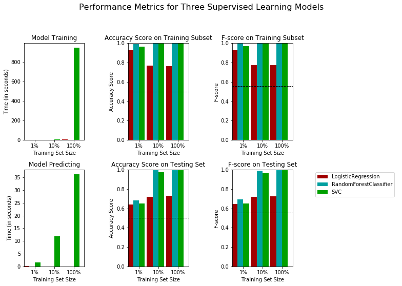

```python
# TODO: Import the three supervised learning models from sklearn
from sklearn.linear_model import LogisticRegression
from sklearn.ensemble import RandomForestClassifier
from sklearn.svm import SVC


# TODO: Initialize the three models
clf_A = LogisticRegression(random_state = 0)
clf_B = RandomForestClassifier(random_state = 0)
clf_C = SVC(random_state = 0)

# TODO: Calculate the number of samples for 1%, 10%, and 100% of the training data
samples_100 = len(X_train)
samples_10 = int(len(X_train)/10)
samples_1 = int(len(X_train)/100)


# Collect results on the learners
results = {}
for clf in [clf_A, clf_B, clf_C]:
    clf_name = clf.__class__.__name__
    results[clf_name] = {}
    for i, samples in enumerate([samples_1, samples_10, samples_100]):
        results[clf_name][i] = \
        train_predict(clf, samples, X_train, y_train, X_test, y_test)

# Run metrics visualization for the three supervised learning models chosen
vs.evaluate(results, accuracy, fscore);
```

Random Forest Classification was extremely fast and accurate so I will be using that for fine tuning and ultimately putting my model into production

```python
# TODO: Import 'GridSearchCV', 'make_scorer', and any other necessary libraries
from sklearn.model_selection import GridSearchCV
from sklearn.metrics import make_scorer

# TODO: Initialize the classifier
clf = RandomForestClassifier(random_state = 0)

# TODO: Create the parameters list you wish to tune, using a dictionary if needed.
# HINT: parameters = {'parameter_1': [value1, value2], 'parameter_2': [value1, value2]}
parameters = {
    "n_estimators": [10, 50, 100],     # Number of trees in the forest
    "max_depth": [None, 10, 20, 30],  # Maximum depth of the trees
    "min_samples_split": [2, 5, 10]  # Minimum samples required to split a node
}

# TODO: Make an fbeta_score scoring object using make_scorer()
scorer = make_scorer(fbeta_score, beta = 0.5)

# TODO: Perform grid search on the classifier using 'scorer' as the scoring method using GridSearchCV()
grid_obj = GridSearchCV(clf, parameters, scoring=scorer)
# TODO: Fit the grid search object to the training data and find the optimal parameters using fit()
grid_fit = grid_obj.fit(X_train, y_train)

# Get the estimator
best_clf = grid_fit.best_estimator_

# Make predictions using the unoptimized and model
predictions = (clf.fit(X_train, y_train)).predict(X_test)
best_predictions = best_clf.predict(X_test)

# Report the before-and-afterscores
print("Unoptimized model\n------")
print("Accuracy score on testing data: {:.4f}".format(accuracy_score(y_test, predictions)))
print("F-score on testing data: {:.4f}".format(fbeta_score(y_test, predictions, beta = 0.5)))
print("\nOptimized Model\n------")
print("Final accuracy score on the testing data: {:.4f}".format(accuracy_score(y_test, best_predictions)))
print("Final F-score on the testing data: {:.4f}".format(fbeta_score(y_test, best_predictions, beta = 0.5)))
```

```
Unoptimized model
------
Accuracy score on testing data: 1.0000
F-score on testing data: 1.0000

Optimized Model
------
Final accuracy score on the testing data: 1.0000
Final F-score on the testing data: 1.0000
```

Now I will look at the feature importance for my top 5 variables

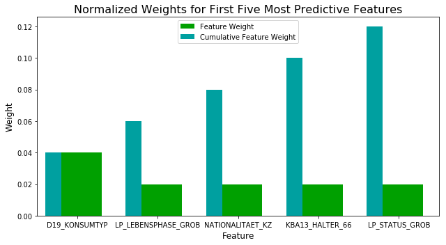

```python
# TODO: Import a supervised learning model that has 'feature_importances_'
from sklearn.ensemble import AdaBoostClassifier

# TODO: Train the supervised model on the training set using .fit(X_train, y_train)
model = AdaBoostClassifier()
model.fit(X_train, y_train)

# TODO: Extract the feature importances using .feature_importances_
importances = model.feature_importances_

# Plot
vs.feature_plot(importances, X_train, y_train)
```

Here we see that no weight makes up a huge portion of the predictability power of the model by itself, which isn't that surprising with the sheer volumn of features we had. D19_KONSUMTYP does have 2x as much weight as any other variability at 4%, which is the consumption type of the customer. So while it isn't of huge importance it is worth noting that it is the top performing feature for predicting the response.

# Test Data

```python
mailout_sub5 = pd.read_csv('mailout_sub5.csv')
```

```python
mailout_test = pd.read_csv('../../data/Term2/capstone/arvato_data/Udacity_MAILOUT_052018_TEST.csv', sep=';')
mailout_test.shape
```

```
(42833, 366)
```

```python
mailout_test.head(5)
```

|  | LNR | AGER_TYP | AKT_DAT_KL | ALTER_HH | ALTER_KIND1 | ALTER_KIND2 | ALTER_KIND3 | ALTER_KIND4 | ALTERSKATEGORIE_FEIN | ANZ_HAUSHALTE_AKTIV | ... | VHN | VK_DHT4A | VK_DISTANZ | VK_ZG11 | W_KEIT_KIND_HH | WOHNDAUER_2008 | WOHNLAGE | ZABEOTYP | ANREDE_KZ | ALTERSKATEGORIE_GROB |
| --- | --- | --- | --- | --- | --- | --- | --- | --- | --- | --- | --- | --- | --- | --- | --- | --- | --- | --- | --- | --- | --- |
| 0 | 1754 | 2 | 1.0 | 7.0 | NaN | NaN | NaN | NaN | 6.0 | 2.0 | ... | 4.0 | 5.0 | 6.0 | 3.0 | 6.0 | 9.0 | 3.0 | 3 | 1 | 4 |
| 1 | 1770 | -1 | 1.0 | 0.0 | NaN | NaN | NaN | NaN | 0.0 | 20.0 | ... | 1.0 | 5.0 | 2.0 | 1.0 | 6.0 | 9.0 | 5.0 | 3 | 1 | 4 |
| 2 | 1465 | 2 | 9.0 | 16.0 | NaN | NaN | NaN | NaN | 11.0 | 2.0 | ... | 3.0 | 9.0 | 6.0 | 3.0 | 2.0 | 9.0 | 4.0 | 3 | 2 | 4 |
| 3 | 1470 | -1 | 7.0 | 0.0 | NaN | NaN | NaN | NaN | 0.0 | 1.0 | ... | 2.0 | 6.0 | 6.0 | 3.0 | NaN | 9.0 | 2.0 | 3 | 2 | 4 |
| 4 | 1478 | 1 | 1.0 | 21.0 | NaN | NaN | NaN | NaN | 13.0 | 1.0 | ... | 1.0 | 2.0 | 4.0 | 3.0 | 3.0 | 9.0 | 7.0 | 4 | 2 | 4 |

5 rows × 366 columns

```python
test_lnr = mailout_test['LNR']
mailout_test.drop(['LNR'], axis=1, inplace=True)
```

```python
#load in xlsx files that have column metadata and drop if record is incomplete
information = pd.read_excel('DIAS Information Levels - Attributes 2017.xlsx', header=1)
information = information.dropna(subset=['Information level'])

attributes = pd.read_excel('DIAS Attributes - Values 2017.xlsx', header=1)
attributes = attributes.dropna(subset=['Attribute'])
```

```python
#convert all columns from attributes data into a list and drop any missing columns from the dataframe
features = attributes['Attribute'].tolist()
df_cols_no_feature = list(set(mailout_test) - set(features))
df_cols_no_feature = [col for col in df_cols_no_feature if col != 'RESPONSE']
mailout_test = mailout_test.drop(columns=df_cols_no_feature, errors='ignore')
```

```python
dfnulls = mailout_test.isnull().sum().sort_values(ascending=False)

#create list of columns and the percent of records with a missing value
nan_detail = []

for col in mailout_test.columns:
    nan_count = mailout_test[col].isna().sum()
    total_count = len(mailout_test)
    nan_percent = (nan_count/total_count)*100
    nan_detail.append([col, nan_percent])

nan_detail = pd.DataFrame(nan_detail, columns=['Column', 'NaN Percentage']).sort_values(by='NaN Percentage', ascending=False)
```

```python
# Drop fields for years and also CAMEO_DEU_2015 due to too many unique variables
#mailout_test = mailout_test.drop(['GEBURTSJAHR', 'MIN_GEBAEUDEJAHR', 'CAMEO_DEU_2015'], axis=1)
# Re-encode OST_WEST_KZ
mailout_test.loc[:, 'OST_WEST_KZ'].replace({'W': 0, 'O': 1, np.nan: 0}, inplace=True)

# Re-encode CAMEO_DEUG_2015 to replace nan/X nad convert everything into integers
mailout_test['CAMEO_DEUG_2015'].replace({'X': -1, np.nan: -1, '8.0': 8, '4.0': 4, '2.0': 2, '6.0': 6, '1.0': 1, '9.0': 9, '7.0': 7, '5.0': 5, '3.0': 3, '3': 3, '8': 8, '5': 5, '4': 4, '9': 9, '6': 6, '7': 7, '2': 2, '1': 1}, inplace=True)
```

```python
correlation_matrix = test_sub5.corr()
threshold = 0.85
# Create a set to store columns to drop
columns_to_drop = set()

# Find correlated pairs and add one column to the set of columns to drop
for i in range(len(correlation_matrix.columns)):
    for j in range(i):
        if abs(correlation_matrix.iloc[i, j]) > threshold:
            # Add one of the columns to the set (choose which one to keep)
            columns_to_drop.add(correlation_matrix.columns[j])

test_sub5 = test_sub5.drop(columns=list(columns_to_drop))
test_sub5.shape
```

```
(33525, 243)
```

```python
mailout_test.fillna(method='ffill', inplace=True)
mailout_test.fillna(method='bfill', inplace=True)

mailout_test = mailout_test.astype(float)

# scale features
scaler = StandardScaler()
mailout_test = pd.DataFrame(scaler.fit_transform(mailout_test), columns=mailout_test.columns)
mailout_test.head(5)
```

|  | LP_LEBENSPHASE_GROB | KBA13_KW_90 | KBA13_SEG_SONSTIGE | KBA05_ALTER4 | KBA13_HALTER_66 | KBA13_KRSSEG_KLEIN | SEMIO_KULT | FINANZTYP | KBA13_KW_80 | KBA13_MAZDA | ... | RETOURTYP_BK_S | KBA13_HALTER_60 | KBA05_SEG3 | KBA13_CCM_1000 | KBA13_SITZE_6 | KBA13_BJ_2000 | GEBAEUDETYP_RASTER | ZABEOTYP | KBA05_SEG9 | NaN Count Raw |
| --- | --- | --- | --- | --- | --- | --- | --- | --- | --- | --- | --- | --- | --- | --- | --- | --- | --- | --- | --- | --- | --- |
| 0 | -0.070170 | -1.652437 | -0.056128 | 1.435243 | -1.032207 | 0.029434 | 1.695929 | 0.428851 | -0.246442 | -0.044573 | ... | 1.089130 | 0.018954 | -0.890575 | -0.263369 | -1.030497 | -0.878406 | -0.926831 | 0.178441 | -0.146226 | -0.492386 |
| 1 | -0.740567 | 0.411808 | -0.056128 | -1.780689 | -0.117856 | 0.029434 | 0.495209 | 1.027034 | -0.246442 | -0.044573 | ... | 1.089130 | 0.018954 | -0.051205 | 0.445675 | 0.823043 | 1.177199 | 0.207587 | 0.178441 | -0.975471 | -0.492386 |
| 2 | 1.494089 | -0.276274 | -0.056128 | 0.631260 | 0.796495 | 0.029434 | -0.705510 | -1.365696 | -0.948761 | -0.044573 | ... | 1.089130 | 0.018954 | -1.729944 | -1.681459 | -0.103727 | -1.906209 | 0.207587 | 0.178441 | 1.512265 | -0.492386 |
| 3 | -1.187499 | -0.964355 | 1.003890 | 0.631260 | 1.710845 | 0.029434 | -0.705510 | 1.027034 | -0.246442 | -0.044573 | ... | 1.089130 | 1.883105 | -0.890575 | -0.263369 | -0.103727 | 1.177199 | 0.207587 | 0.178441 | -0.975471 | -0.478521 |
| 4 | 1.494089 | 1.787971 | -2.176164 | 0.631260 | -1.032207 | 0.029434 | -0.705510 | 1.027034 | -1.651080 | -0.044573 | ... | -0.608618 | 0.018954 | -0.051205 | -0.972414 | 0.823043 | 1.177199 | 1.342005 | 1.070811 | -0.146226 | -0.492386 |

5 rows × 241 columns

```python
mailout_test.to_csv('mailout_test.csv', index=False)
```

```python
mailout_test.isna().sum().sum()
mailout_test.shape
```

```
(42833, 241)
```

```python
best_clf
```

```
RandomForestClassifier(bootstrap=True, class_weight=None, criterion='gini',
            max_depth=None, max_features='auto', max_leaf_nodes=None,
            min_impurity_decrease=0.0, min_impurity_split=None,
            min_samples_leaf=1, min_samples_split=2,
            min_weight_fraction_leaf=0.0, n_estimators=10, n_jobs=1,
            oob_score=False, random_state=0, verbose=0, warm_start=False)
```

```python
test_best_clf = best_clf.predict_proba(mailout_test)
```

```python
results = pd.DataFrame({'LNR':test_lnr.astype(np.int32), 'RESPONSE':test_best_clf[:, 1]})

results.to_csv('results.csv', index=False)
```

```python
value_counts = results['RESPONSE'].value_counts()

# Display the count of each unique value
print(value_counts)
```

```
0.0    35000
0.1     7107
0.2      686
0.3       38
0.4        2
Name: RESPONSE, dtype: int64
```